# Education and Stability

Nathan Alexander

Center for Applied Data Science and Analytics (CADSA)

Howard University

2024-12-16

## Introduction

This document provides an overview of the proposed research for the CADSA RDC project. Here, I will highlight the significance of studying the role of education and other correlates in the eviction rates among African Americans and the impact on stability (defined as a measure of housing stability, job security, and related features).

## Literature Review

This section will summarize existing literature on eviction rates, income disparities, education levels, and racial inequities in housing. Key studies and findings will be discussed to provide context for the research questions:

- **Eviction Disparities**: Black households face disproportionately high eviction rates compared to white households. Over 50% of eviction filings in the U.S. are against Black families, despite them comprising only 18.6% of the renter population [1][3]. Black women with children are particularly vulnerable, representing a significant portion of eviction filings [1].
- **Impact of Education**: Research indicates that Black and Latino renters with some college education experience higher rates of nonpayment of rent than their white counterparts [5]. This suggests that education alone does not mitigate the risk of eviction for these groups.
- **Health Implications**: Eviction is linked to adverse health outcomes, particularly among Black children and families. The stress associated with eviction can lead to various health issues, including low birth weights and cognitive development challenges [1].
- **Economic Factors**: The relationship between income and eviction is complex; even Black households earning over $80,000 experience higher eviction risks than white households earning under $20,000 [1][3]. This disparity highlights systemic issues beyond individual income levels.
- **Racial and Economic Segregation**: Areas with high rates of racial segregation often see higher eviction rates. For example, Atlanta is noted for its significant racial segregation and high poverty rates, which contribute to elevated eviction rates among low-income households [2].

## Research Questions

1. **Demographic Analysis**:
   - How do eviction rates differ among individuals identified as Black or African American in areas with varying levels of education?
2. **Income Correlation**:
   - What is the relationship between low-income status and eviction rates among African Americans?
3. **Education Impact**:
   - How does educational attainment influence eviction rates among African Americans?
4. **Spatial Analysis**:
   - How does geographic location influence the likelihood of eviction among lower-income Black or African American individuals?

## Data and Methods

This section will describe the datasets used (CJARS and Census data), the methods for linking these datasets, and the statistical techniques employed to analyze the data.

### Data Sources

- **CJARS**: Overview of CJARS data relevant to the study.
- **Census Data**: Description of ACS variables used in the analysis.

### Methods

- Description of statistical methods (e.g., regression analysis, calculation of dissimilarity and isolation indices) that will be applied to answer the research questions.

## R Code to Access Data

```r
# Load necessary libraries
library(tidycensus)
library(dplyr)
```

```r
library(ggplot2)
# options(tigris_use_cache = TRUE)

# Set your Census API key
# census_api_key("YOUR_CENSUS_API_KEY", install = TRUE)

# Define variables of interest
variables <- c(
  total_population = "B01001_001",         # Total Population
  black_population = "B03002_004",         # Black or African American Population
  lower_income = "B19001_002",             # Households with income less than $10,000
  median_home_value = "B25077_001",        # Median Home Value
  public_housing = "B25003_002",           # Occupied housing units that are renter-occupied and subsidized
  public_assistance = "B19058_001",        # Households Receiving Public Assistance
  median_household_income = "B19013_001",  # Median Household Income
  bachelor = "B15003_017",                 # Population over 25 with a Bachelor's degree or higher
  white_population = "B03002_003",         # White Population
  hispanic_population = "B03002_012",      # Hispanic or Latino Population
  male_population = "B01001_002",          # Male Population
  female_population = "B01001_026",        # Female Population
  median_age = "B01002_001",               # Median Age
  employed = "B23025_002",                 # Employed population (age 16+)
  unemployed = "B23025_003",               # Unemployed population (age 16+)
  children_under_18 = "B09001_001"         # Total number of own children under 18 years
  )


get_census_data <- function(year) {
  census_data <- get_acs(
    geography = "tract",
    variables = variables,
    year = year,
    state = "DC", # Change to your state of interest
    output = "wide"
  )
}
```

```r
# check function, wide format data
df1 <- get_census_data(2022)
df1
```

```
## # A tibble: 206 × 34
##    GEOID       NAME        total_populationE total_populationM black_populationE
##    <chr>       <chr>                   <dbl>             <dbl>             <dbl>
##  1 11001000101 Census Tra…              1097               223                26
##  2 11001000102 Census Tra…              3127               474                26
##  3 11001000201 Census Tra…              2384                35               203
##  4 11001000202 Census Tra…              3919               461               154
##  5 11001000300 Census Tra…              5979               782               156
##  6 11001000400 Census Tra…              1652               331                27
##  7 11001000501 Census Tra…              3594               465               427
##  8 11001000502 Census Tra…              3384               524               148
##  9 11001000600 Census Tra…              4548               564               397
## 10 11001000702 Census Tra…              2921               433               525
## # ℹ 196 more rows
## # ℹ 29 more variables: black_populationM <dbl>, lower_incomeE <dbl>,
## #   lower_incomeM <dbl>, median_home_valueE <dbl>, median_home_valueM <dbl>,
## #   public_housingE <dbl>, public_housingM <dbl>, public_assistanceE <dbl>,
## #   public_assistanceM <dbl>, median_household_incomeE <dbl>,
## #   median_household_incomeM <dbl>, bachelorE <dbl>, bachelorM <dbl>,
## #   white_populationE <dbl>, white_populationM <dbl>, …
```

```r
# load data for year directly from ACS
df2 <- get_acs(
  geography = "tract",
  variables = variables,
  state = "DC",
  year = 2022,
  geometry = TRUE
)
df2
```

```
## Simple feature collection with 3296 features and 5 fields
## Geometry type: POLYGON
## Dimension:     XY
## Bounding box:  xmin: -77.11976 ymin: 38.79165 xmax: -76.9094 ymax: 38.99511
## Geodetic CRS:  NAD83
## First 10 features:
##          GEOID                                                          NAME
## 1  11001000201 Census Tract 2.01; District of Columbia; District of Columbia
## 2  11001000201 Census Tract 2.01; District of Columbia; District of Columbia
## 3  11001000201 Census Tract 2.01; District of Columbia; District of Columbia
## 4  11001000201 Census Tract 2.01; District of Columbia; District of Columbia
## 5  11001000201 Census Tract 2.01; District of Columbia; District of Columbia
## 6  11001000201 Census Tract 2.01; District of Columbia; District of Columbia
## 7  11001000201 Census Tract 2.01; District of Columbia; District of Columbia
## 8  11001000201 Census Tract 2.01; District of Columbia; District of Columbia
## 9  11001000201 Census Tract 2.01; District of Columbia; District of Columbia
## 10 11001000201 Census Tract 2.01; District of Columbia; District of Columbia
##               variable estimate   moe                       geometry
## 1     total_population   2384.0  35.0 POLYGON ((-77.07902 38.9126...
## 2      male_population    999.0 108.0 POLYGON ((-77.07902 38.9126...
## 3    female_population   1385.0 105.0 POLYGON ((-77.07902 38.9126...
## 4           median_age     19.8   0.3 POLYGON ((-77.07902 38.9126...
## 5     white_population   1219.0 168.0 POLYGON ((-77.07902 38.9126...
## 6     black_population    203.0 118.0 POLYGON ((-77.07902 38.9126...
## 7  hispanic_population    309.0  92.0 POLYGON ((-77.07902 38.9126...
## 8    children_under_18     27.0  27.0 POLYGON ((-77.07902 38.9126...
## 9             bachelor     12.0  30.0 POLYGON ((-77.07902 38.9126...
## 10        lower_income      0.0  14.0 POLYGON ((-77.07902 38.9126...
```

```r
# Create df1: Calculate percentages for Black population and lower income
df1 <- df1 %>%
  mutate(
    black_only_percentage = black_populationE / total_populationE * 100,
    low_income_percentage = lower_incomeE / total_populationE * 100
  ) %>%
  filter(black_only_percentage > 0 & low_income_percentage > 0) # Filter for relevant data

# View df1
print(df1)
```

```
## # A tibble: 191 × 36
##    GEOID       NAME        total_populationE total_populationM black_populationE
##    <chr>       <chr>                   <dbl>             <dbl>             <dbl>
##  1 11001000202 Census Tra…              3919               461               154
##  2 11001000300 Census Tra…              5979               782               156
##  3 11001000400 Census Tra…              1652               331                27
##  4 11001000501 Census Tra…              3594               465               427
##  5 11001000502 Census Tra…              3384               524               148
##  6 11001000600 Census Tra…              4548               564               397
##  7 11001000702 Census Tra…              2921               433               525
##  8 11001000703 Census Tra…              2978               497               276
##  9 11001000704 Census Tra…              2660               420                81
## 10 11001000802 Census Tra…              3306               427               212
## # ℹ 181 more rows
## # ℹ 31 more variables: black_populationM <dbl>, lower_incomeE <dbl>,
## #   lower_incomeM <dbl>, median_home_valueE <dbl>, median_home_valueM <dbl>,
## #   public_housingE <dbl>, public_housingM <dbl>, public_assistanceE <dbl>,
## #   public_assistanceM <dbl>, median_household_incomeE <dbl>,
## #   median_household_incomeM <dbl>, bachelorE <dbl>, bachelorM <dbl>,
## #   white_populationE <dbl>, white_populationM <dbl>, …
```

```r
df3 <- df1 %>%
  mutate(
    black_only_percentage = black_populationE / total_populationE * 100,
    low_income_percentage = lower_incomeE / total_populationE * 100,
    median = median_home_valueE,
    assist = public_assistanceE
  ) %>%
  filter(black_only_percentage > 50 &
           low_income_percentage > mean(low_income_percentage) # return values above the mean
         ) # Filter for relevant data

# View df2
print(df3)
```

```
## # A tibble: 46 × 38
##    GEOID       NAME        total_populationE total_populationM black_populationE
##    <chr>       <chr>                   <dbl>             <dbl>             <dbl>
##  1 11001002102 Census Tra…              4768               673              2749
##  2 11001002301 Census Tra…              3233               560              1743
##  3 11001004704 Census Tra…              1226               413              1027
##  4 11001006400 Census Tra…              2662               514              1902
##  5 11001007304 Census Tra…              4927               940              4596
##  6 11001007401 Census Tra…              1407               314              1250
##  7 11001007403 Census Tra…              2421               577              1984
##  8 11001007404 Census Tra…              3958               631              3547
##  9 11001007406 Census Tra…              3033               765              2697
## 10 11001007407 Census Tra…              3216               596              2940
## # ℹ 36 more rows
## # ℹ 33 more variables: black_populationM <dbl>, lower_incomeE <dbl>,
## #   lower_incomeM <dbl>, median_home_valueE <dbl>, median_home_valueM <dbl>,
## #   public_housingE <dbl>, public_housingM <dbl>, public_assistanceE <dbl>,
## #   public_assistanceM <dbl>, median_household_incomeE <dbl>,
## #   median_household_incomeM <dbl>, bachelorE <dbl>, bachelorM <dbl>,
## #   white_populationE <dbl>, white_populationM <dbl>, …
```

```r
# Load necessary libraries
library(dplyr)
library(ggplot2)

# Assuming df3 is your final dataset with relevant columns
# Check the structure of df3
str(df2)
```

```
## Classes 'sf' and 'data.frame':   3296 obs. of  6 variables:
##  $ GEOID   : chr  "11001000201" "11001000201" "11001000201" "11001000201" ...
##  $ NAME    : chr  "Census Tract 2.01; District of Columbia; District of Columbia" "Census Tract 2.01; District of Columbia; District of Columbia" "Census Tract 2.01; District of Columbia; District of Columbia" "Census Tract 2.01; District of Columbia; District of Columbia" ...
##  $ variable: chr  "total_population" "male_population" "female_population" "median_age" ...
##  $ estimate: num  2384 999 1385 19.8 1219 ...
##  $ moe     : num  35 108 105 0.3 168 118 92 27 30 14 ...
##  $ geometry:sfc_POLYGON of length 3296; first list element: List of 1
##   ..$ : num [1:13, 1:2] -77.1 -77.1 -77.1 -77.1 -77.1 ...
##   ..- attr(*, "class")= chr [1:3] "XY" "POLYGON" "sfg"
##  - attr(*, "sf_column")= chr "geometry"
##  - attr(*, "agr")= Factor w/ 3 levels "constant","aggregate",..: NA NA NA NA NA
##   ..- attr(*, "names")= chr [1:5] "GEOID" "NAME" "variable" "estimate" ...
```

```r
# Build a linear regression model
# For example, predicting median home value based on other variables
model <- lm(median_home_valueE ~ black_only_percentage + low_income_percentage + public_assistanceE, data = df1)

# Summarize the model to see coefficients and overall fit
summary(model)
```

```
##
## Call:
## lm(formula = median_home_valueE ~ black_only_percentage + low_income_percentage +
##     public_assistanceE, data = df1)
##
## Residuals:
##     Min      1Q  Median      3Q     Max
## -705788 -131199  -12307  103419  899538
##
## Coefficients:
##                         Estimate Std. Error t value Pr(>|t|)
## (Intercept)           1152882.71   66246.90  17.403  < 2e-16 ***
## black_only_percentage   -5276.24     548.87  -9.613  < 2e-16 ***
## low_income_percentage  -19855.78    5527.02  -3.592 0.000422 ***
## public_assistanceE        -86.36      34.92  -2.473 0.014324 *
## ---
## Signif. codes:  0 '***' 0.001 '**' 0.01 '*' 0.05 '.' 0.1 ' ' 1
##
## Residual standard error: 228500 on 181 degrees of freedom
##   (6 observations deleted due to missingness)
## Multiple R-squared:  0.442,  Adjusted R-squared:  0.4327
## F-statistic: 47.79 on 3 and 181 DF,  p-value: < 2.2e-16
```

#### black_only_percentage

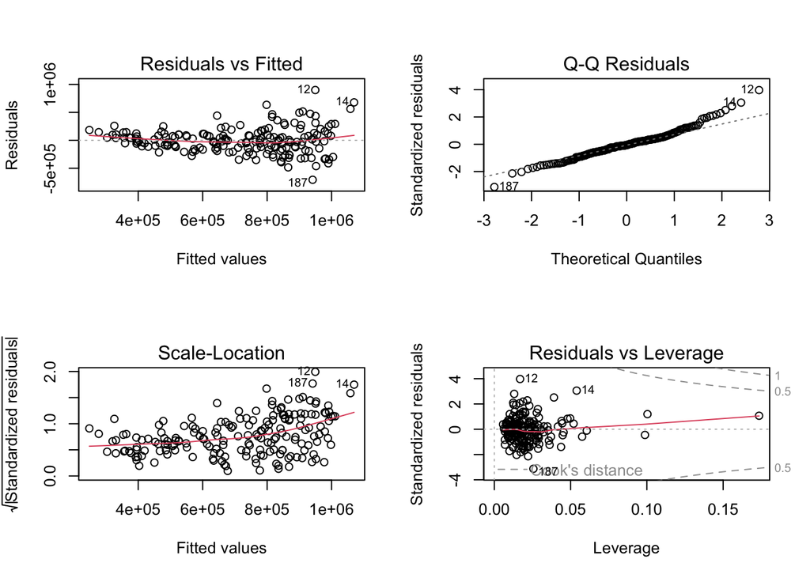

```r
# Evaluate model fit with diagnostic plots
par(mfrow = c(2, 2))  # Set up a 2x2 plotting area
plot(model)
```

```r
# Reset plotting area
par(mfrow = c(1, 1))
```

```r
# Load necessary libraries
library(dplyr)
library(ggplot2)
library(sf)
library(tigris)
# Assuming df3 is your final dataset with relevant columns
# Check the structure of df3
str(df2)
```

```
## Classes 'sf' and 'data.frame':   3296 obs. of  6 variables:
##  $ GEOID   : chr  "11001000201" "11001000201" "11001000201" "11001000201" ...
##  $ NAME    : chr  "Census Tract 2.01; District of Columbia; District of Columbia" "Census Tract 2.01; District of Columbia; District of Columbia" "Census Tract 2.01; District of Columbia; District of Columbia" "Census Tract 2.01; District of Columbia; District of Columbia" ...
##  $ variable: chr  "total_population" "male_population" "female_population" "median_age" ...
##  $ estimate: num  2384 999 1385 19.8 1219 ...
##  $ moe     : num  35 108 105 0.3 168 118 92 27 30 14 ...
##  $ geometry:sfc_POLYGON of length 3296; first list element: List of 1
##   ..$ : num [1:13, 1:2] -77.1 -77.1 -77.1 -77.1 -77.1 ...
##   ..- attr(*, "class")= chr [1:3] "XY" "POLYGON" "sfg"
##  - attr(*, "sf_column")= chr "geometry"
##  - attr(*, "agr")= Factor w/ 3 levels "constant","aggregate",..: NA NA NA NA NA
##   ..- attr(*, "names")= chr [1:5] "GEOID" "NAME" "variable" "estimate" ...
```

```r
# Create a new variable for isolation index (optional)
# You can define your own method for calculating isolation
df4 <- df1 %>%
  mutate(isolation_index = black_only_percentage + low_income_percentage / (total_populationE) * 100)
df4 %>% summary(isolation_index)
```

```
##     GEOID               NAME           total_populationE total_populationM
##  Length:191         Length:191         Min.   :1226      Min.   : 176.0
##  Class :character   Class :character   1st Qu.:2546      1st Qu.: 427.0
##  Mode  :character   Mode  :character   Median :3236      Median : 536.0
##                                        Mean   :3325      Mean   : 565.9
##                                        3rd Qu.:3966      3rd Qu.: 674.5
##                                        Max.   :6923      Max.   :1241.0
##
##  black_populationE black_populationM lower_incomeE   lower_incomeM
##  Min.   :   1.0    Min.   :   2.0    Min.   :  1.0   Min.   :  2.00
##  1st Qu.: 345.5    1st Qu.: 160.0    1st Qu.: 42.0   1st Qu.: 43.50
##  Median :1156.0    Median : 361.0    Median : 97.0   Median : 73.00
##  Mean   :1481.0    Mean   : 399.8    Mean   :121.9   Mean   : 86.51
##  3rd Qu.:2306.5    3rd Qu.: 575.0    3rd Qu.:166.5   3rd Qu.:109.50
##  Max.   :5720.0    Max.   :1353.0    Max.   :497.0   Max.   :330.00
##
##  median_home_valueE median_home_valueM public_housingE  public_housingM
##  Min.   : 235400    Min.   : 14156     Min.   :   0.0   Min.   : 14.0
##  1st Qu.: 467200    1st Qu.: 57111     1st Qu.: 385.0   1st Qu.:105.5
##  Median : 653700    Median : 88232     Median : 606.0   Median :154.0
##  Mean   : 714404    Mean   :117655     Mean   : 639.2   Mean   :169.3
##  3rd Qu.: 878300    3rd Qu.:143894     3rd Qu.: 842.5   3rd Qu.:207.5
##  Max.   :1848900    Max.   :603852     Max.   :1932.0   Max.   :658.0
##  NA's   :6          NA's   :6
##  public_assistanceE public_assistanceM median_household_incomeE
##  Min.   : 358       Min.   : 68.0      Min.   : 14827
##  1st Qu.:1227       1st Qu.:179.0      1st Qu.: 67673
##  Median :1565       Median :231.0      Median :103776
##  Mean   :1583       Mean   :246.6      Mean   :111431
##  3rd Qu.:1920       3rd Qu.:307.5      3rd Qu.:141215
##  Max.   :2931       Max.   :772.0      Max.   :250001
##                                        NA's   :1
##  median_household_incomeM   bachelorE        bachelorM     white_populationE
##  Min.   : 1503            Min.   :   0.0   Min.   :  6.0   Min.   :   0
##  1st Qu.:17471            1st Qu.:  84.5   1st Qu.: 61.5   1st Qu.: 265
##  Median :26457            Median : 234.0   Median :126.0   Median :1101
##  Mean   :28534            Mean   : 309.6   Mean   :145.6   Mean   :1178
##  3rd Qu.:36237            3rd Qu.: 456.0   3rd Qu.:207.5   3rd Qu.:1832
##  Max.   :85849            Max.   :1540.0   Max.   :561.0   Max.   :3987
##  NA's   :6
```

[output cut: 25 more lines]

```
##  Min.   :   0.0     Min.   :  3.0      Min.   : 0.05974
##  1st Qu.: 297.0     1st Qu.:122.5      1st Qu.:11.13630
##  Median : 516.0     Median :204.0      Median :36.88338
##  Mean   : 620.2     Mean   :238.7      Mean   :43.22537
##  3rd Qu.: 935.0     3rd Qu.:324.5      3rd Qu.:77.05228
##  Max.   :2391.0     Max.   :805.0      Max.   :99.22058
##
##  low_income_percentage isolation_index
##  Min.   : 0.04115      Min.   : 0.2703
##  1st Qu.: 1.36513      1st Qu.:11.2521
##  Median : 3.05574      Median :36.9698
##  Mean   : 3.78910      Mean   :43.3588
##  3rd Qu.: 4.97032      3rd Qu.:77.1643
##  Max.   :18.71379      Max.   :99.4143
##
```

```r
library(tmap)
```

```r
# Filter for low-income Black residents (for example, those with low_income_percentage > 20)
low_income_black_residents <- df4 %>%
  filter(isolation_index > 75)

iso <- get_acs(
  geography = "tract",
  state = "DC",
  variables = variables,
  year = 2022,
  geometry = TRUE)
iso
```

```
## Simple feature collection with 3296 features and 5 fields
## Geometry type: POLYGON
## Dimension:     XY
## Bounding box:  xmin: -77.11976 ymin: 38.79165 xmax: -76.9094 ymax: 38.99511
## Geodetic CRS:  NAD83
## First 10 features:
##          GEOID                                                          NAME
## 1  11001000201 Census Tract 2.01; District of Columbia; District of Columbia
## 2  11001000201 Census Tract 2.01; District of Columbia; District of Columbia
## 3  11001000201 Census Tract 2.01; District of Columbia; District of Columbia
## 4  11001000201 Census Tract 2.01; District of Columbia; District of Columbia
## 5  11001000201 Census Tract 2.01; District of Columbia; District of Columbia
## 6  11001000201 Census Tract 2.01; District of Columbia; District of Columbia
## 7  11001000201 Census Tract 2.01; District of Columbia; District of Columbia
## 8  11001000201 Census Tract 2.01; District of Columbia; District of Columbia
## 9  11001000201 Census Tract 2.01; District of Columbia; District of Columbia
## 10 11001000201 Census Tract 2.01; District of Columbia; District of Columbia
##               variable estimate   moe                       geometry
## 1     total_population   2384.0  35.0 POLYGON ((-77.07902 38.9126...
## 2      male_population    999.0 108.0 POLYGON ((-77.07902 38.9126...
## 3    female_population   1385.0 105.0 POLYGON ((-77.07902 38.9126...
## 4           median_age     19.8   0.3 POLYGON ((-77.07902 38.9126...
## 5     white_population   1219.0 168.0 POLYGON ((-77.07902 38.9126...
## 6     black_population    203.0 118.0 POLYGON ((-77.07902 38.9126...
## 7  hispanic_population    309.0  92.0 POLYGON ((-77.07902 38.9126...
## 8    children_under_18     27.0  27.0 POLYGON ((-77.07902 38.9126...
## 9             bachelor     12.0  30.0 POLYGON ((-77.07902 38.9126...
## 10        lower_income      0.0  14.0 POLYGON ((-77.07902 38.9126...
```

```r
clt <- get_acs(
  geography = "tract",
  state = "NC",
  county = "Mecklenburg",
  variables = variables,
  year = 2022,
  geometry = TRUE)
clt
```

```
## Simple feature collection with 4880 features and 5 fields
## Geometry type: MULTIPOLYGON
## Dimension:     XY
## Bounding box:  xmin: -81.05803 ymin: 35.00162 xmax: -80.55035 ymax: 35.51479
## Geodetic CRS:  NAD83
## First 10 features:
##          GEOID                                                NAME
## 1  37119005200 Census Tract 52; Mecklenburg County; North Carolina
## 2  37119005200 Census Tract 52; Mecklenburg County; North Carolina
## 3  37119005200 Census Tract 52; Mecklenburg County; North Carolina
## 4  37119005200 Census Tract 52; Mecklenburg County; North Carolina
## 5  37119005200 Census Tract 52; Mecklenburg County; North Carolina
## 6  37119005200 Census Tract 52; Mecklenburg County; North Carolina
## 7  37119005200 Census Tract 52; Mecklenburg County; North Carolina
## 8  37119005200 Census Tract 52; Mecklenburg County; North Carolina
## 9  37119005200 Census Tract 52; Mecklenburg County; North Carolina
## 10 37119005200 Census Tract 52; Mecklenburg County; North Carolina
##               variable estimate   moe                       geometry
## 1     total_population   1932.0 230.0 MULTIPOLYGON (((-80.84089 3...
## 2      male_population    919.0 221.0 MULTIPOLYGON (((-80.84089 3...
## 3    female_population   1013.0 186.0 MULTIPOLYGON (((-80.84089 3...
## 4           median_age     33.8   2.8 MULTIPOLYGON (((-80.84089 3...
## 5     white_population    218.0 101.0 MULTIPOLYGON (((-80.84089 3...
## 6     black_population   1446.0 210.0 MULTIPOLYGON (((-80.84089 3...
## 7  hispanic_population    227.0 205.0 MULTIPOLYGON (((-80.84089 3...
## 8    children_under_18    298.0 194.0 MULTIPOLYGON (((-80.84089 3...
## 9             bachelor    308.0 109.0 MULTIPOLYGON (((-80.84089 3...
## 10        lower_income     68.0  50.0 MULTIPOLYGON (((-80.84089 3...
```

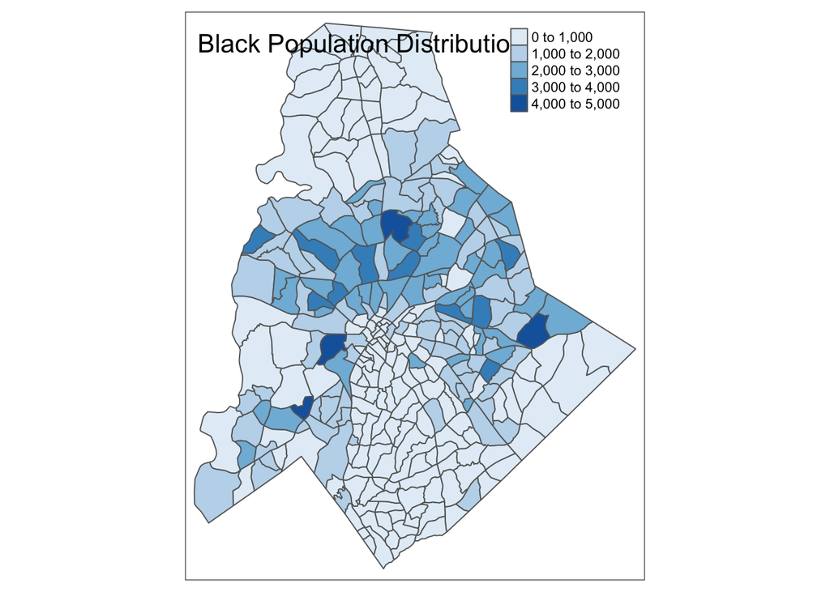

```r
library(dplyr)

# Assuming 'clt' is your data frame and 'variable' is a column that includes 'black_population'
clt_black_pop <- clt %>%
  filter(variable == "black_population")  # Use filter() to select rows where 'variable' equals 'black_population'


# Assuming 'clt' is your spatial data frame and 'black_population' is a column in it
tm_shape(clt_black_pop) +
  tm_polygons(col = "estimate",
               title = "",
               palette = "Blues") +
  tm_layout(title = "Black Population Distribution")
```

```r
summary(df)
summary(df$public_assistanceE)
```

```r
library(tidycensus)
library(ggiraph)
library(tidyverse)
library(patchwork)
library(scales)

dc <- get_acs(
  geography = "county",
  variables = variables,
  state = "DC",
  year = 2022,
  geometry = TRUE
) %>%
  mutate(NAME = str_remove(NAME, " County, Washington"))

dc_map <- ggplot(dc, aes(fill = estimate)) +
  geom_sf_interactive(aes(data_id = GEOID)) +
  scale_fill_distiller(palette = "Greens",
                       direction = 1,
                       guide = "none") +
  theme_void()

dc_map
iso
# Assuming dc_map is your data frame and contains columns: estimate and moe (margin of error)
p <- ggplot(iso, aes(x = estimate, y = reorder(variable, estimate), fill = estimate)) +
  geom_bar(stat = "identity") +  # Use geom_bar for bar plots
  geom_errorbar(aes(ymin = estimate - moe, ymax = estimate + moe), width = 0.2) +  # Add error bars
  labs(title = "Estimates with Margin of Error",
       x = "Estimate",
       y = "Variable") +
  theme_minimal()

# Print the plot
print(p)
```

```r
library(tidycensus)
library(ggiraph)
library(tidyverse)
library(patchwork)
library(scales)

vt_income <- get_acs(
  geography = "county",
  variables = "B19013_001",
  state = "NC",
  year = 2020,
  geometry = TRUE
) %>%
  mutate(NAME = str_remove(NAME, " County, North Carolina"))

vt_map <- ggplot(vt_income, aes(fill = estimate)) +
  geom_sf_interactive(aes(data_id = GEOID)) +
  scale_fill_distiller(palette = "Greens",
                       direction = 1,
                       guide = "none") +
  theme_void()

vt_plot <- ggplot(vt_income, aes(x = estimate, y = reorder(NAME, estimate),
                                 fill = estimate)) +
  geom_errorbar(aes(xmin = estimate - moe, xmax = estimate + moe)) +
  geom_point_interactive(color = "black", size = 4, shape = 21,
                         aes(data_id = GEOID)) +
  scale_fill_distiller(palette = "Greens", direction = 1,
                       labels = label_dollar()) +
  scale_x_continuous(labels = label_dollar()) +
  labs(title = "Household income by county in DC",
       subtitle = "2016-2020 American Community Survey",
       y = "",
       x = "ACS estimate (bars represent margin of error)",
       fill = "ACS estimate") +
  theme_minimal(base_size = 14)

girafe(ggobj = vt_map + vt_plot, width_svg = 10, height_svg = 5) %>%
  girafe_options(opts_hover(css = "fill:cyan;"))
```